# Coursera Data Science Capstone Project: Milestone Report

Eakalak Suthampan

May 12, 2017

# 1 Executive Summary

This Capstone project uses the dataset [Coursera-SwiftKey](https://d396qusza40orc.cloudfront.net/dsscapstone/dataset/Coursera-SwiftKey.zip) to train a model to predict the next word based on the previous 1, 2, or 3 words.

This is a Milestone Report and the goal of this report is performing exploratory analysis of the dataset to understand the distribution of words and relationship between the words. The [n-gram](https://en.wikipedia.org/wiki/N-gram) will be used to show the relationships between words and their frequencies.

The n-grams are built on the entire datasets (twitter+news+blogs) instead of just a sampling by using the library text2vec. The executions time is acceptable if the low frequent terms (frequency < 2) are prune out.

# 2 Loading The Data

The [Coursera-SwiftKey](https://d396qusza40orc.cloudfront.net/dsscapstone/dataset/Coursera-SwiftKey.zip) consists of Twitter, News, Blogs datasets. These datasets will be used to build n-grams.

[profanity words](http://www.bannedwordlist.com/lists/swearWords.txt) will be removed from the datasets in the cleaning process.

# 3 Basic Summaries Of The Data Sets

Basic Summaries Of The Data Sets

| Dataset | Size in MB | Number of Lines | Total Words | Avg. Words Per Line | Max Character in One Line |
| --- | --- | --- | --- | --- | --- |
| twitter | 159 | 2360148 | 30657929 | 13 | 213 |
| news | 196 | 1010242 | 34797994 | 34 | 11384 |
| blog | 200 | 899288 | 38171210 | 42 | 40835 |

# 4 Cleaning The Data

merge the datasets (twitter, news, blogs) then clean the merged dataset. The cleaning are

- to lowercase, remove number
- remove url, email, hashtag
- remove non-ascii character (not english character will be removed)
- remove punctuation except apostrophe and period
- remove profanity words
- strip whitspace

I choose to keep apostrophe (’) and period (.) and do not stemming words and do not remove stopwords. So that the ngram terms look more make sense.

```
## cleaning data: execution time is  318.2415 secs
```

# 5 Building Ngram Terms Count

I built n-grams on the entire dataset (twitter+news+blogs) instead of just a sampling. The text2vec library is used to build n-grams (n-gram terms and their count). The execution time is acceptable if the low frequent terms (frequency < 2) are prune out. text2vec is much faster and less memory consume than the library(tm). I can run the entire data on my laptop 12G Ram, X86_64 Dual Cores CPU.

## 5.1 Building Fourgram

```
## building fourgram: execution time is  441.7694 secs
```

```
##                    terms count
## 1         the end of the  7707
## 2        the rest of the  6689
## 3          at the end of  6648
## 4  thanks for the follow  6159
## 5     for the first time  6132
## 6       at the same time  5159
## 7         is going to be  4395
## 8        one of the most  4226
## 9          is one of the  4169
## 10      when it comes to  4051
```

## 5.2 Building Trigram

```
## building trigram: execution time is  482.4901 secs
```

```
##             terms count
## 1      one of the 34552
## 2        a lot of 30008
## 3  thanks for the 23750
## 4         to be a 18195
## 5     going to be 17419
## 6      the end of 14930
## 7       i want to 14916
## 8      out of the 14773
## 9        it was a 14221
## 10     as well as 13881
```

## 5.3 Building Bigram

```
## building bigram: execution time is  323.1492 secs
```

```
##       terms  count
## 1    of the 430211
## 2    in the 410246
## 3    to the 213395
## 4   for the 200869
## 5    on the 196315
## 6     to be 161790
## 7    at the 142587
## 8   and the 125508
## 9      in a 119771
## 10 with the 105861
```

## 5.4 Building Onegram

```
## building onegram: execution time is  91.77324 secs
```

```
##     terms   count
##  1:   the 4759850
##  2:    to 2753124
##  3:   and 2403834
##  4:     a 2376654
##  5:    of 2005351
##  6:    in 1644260
##  7:     i 1638364
##  8:   for 1100228
##  9:    is 1073005
## 10:  that 1038460
```

## 5.5 Save Ngrams To Files

Transform ngrams from “terms”, “count” into “current_state”, “next_state”, “count” for easy of searching in ngrams then save to files for later use in prediction. for example,

```
##             terms count
## 1: the end of the  7707
```

```
## [1] "transform to"
```

```
##    current_state next_state count
## 1:    the end of        the  7707
```

## 5.6 Terms Count Summary

Ngram terms count summary using the entire data (twitter, news, blogs). Terms count < 2 are prune out for bigram, trigram, fourgram. Onegram does not prune.

Terms Count Summary

[output not shown]

# 6 Exploratory Data Analyses

This section will show relationships between words and their frequency for each ngram.

## 6.1 Most Frequent Terms Wordclouds

The frequent terms in wordclouds show a lot of stop words. But I think the terms looks more make sense than if removing stop words.

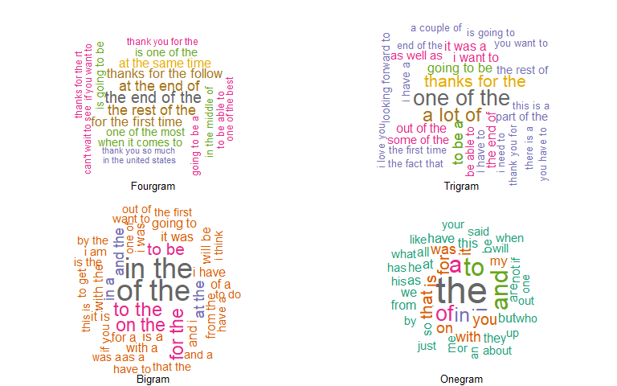

## 6.2 Most frequent Terms Bar Plots

The order of the frequencies scale are onegram frequency > bigram frequency > trigram frequency > fourgram frequency.

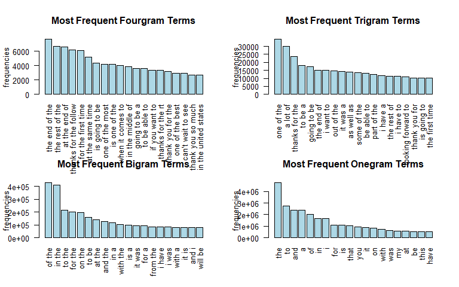

## 6.3 Terms Count Boxplots

All boxplots show that almost all of the count are at the very begining while outliers have a very long spread far away.

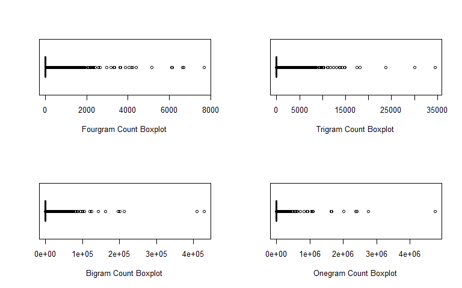

# 7 Next Steps

- Learn about “Smoothing techniques” (techniques to handle when word is unseen in ngram) to predict the top 3-5 possible next words. The interesting techniques are [“backoff” and “interpolation”](http://l2r.cs.uiuc.edu/~danr/Teaching/CS546-09/Lectures/Lec5-Stat-09-ext.pdf).
- To evaluate the model, I will try [Next word prediction benchmark](https://github.com/hfoffani/dsci-benchmark).
- Things to determine.
  - which smoothing techniques, backoff or interpolation?
  - use fivegram, fourgram or trigram at most?
  - min count of word to prune out from ngram?

# 8 Appendix

**Loading The Data**

```r
# download data if not exist
if(!file.exists("Coursera-SwiftKey.zip")) {
        download.file("https://d396qusza40orc.cloudfront.net/dsscapstone/dataset/Coursera-SwiftKey.zip","Coursera-SwiftKey.zip")
        unzip("Coursera-SwiftKey.zip")
}
if(!file.exists("swearWords.txt")) {
        download.file("http://www.bannedwordlist.com/lists/swearWords.txt","swearWords.txt")
}

# Read data
file1 <- "final/en_US/en_US.twitter.txt"
file2 <- "final/en_US/en_US.news.txt"
file3 <- "final/en_US/en_US.blogs.txt"
file4 <- "swearWords.txt"       # profanity words that will be removed from the dataset
con <- file(file1)
twitter.raw <- readLines(con, warn = FALSE)
close(con)
con <- file(file2, open = "rb")
#news.raw <- readLines(con, encoding = "UTF-8", skipNul = TRUE, warn = FALSE)
news.raw <- readLines(con, encoding = "ASCII", skipNul = TRUE, warn = FALSE)
close(con)
con <- file(file3)
blogs.raw <- readLines(con, warn = FALSE)
close(con)
con <- file(file4)
profanity_words <- readLines(con, warn = FALSE)
close(con)
```

**Basic Summaries Of The Data Sets**

```r
twitter.wordcnt <- sum(sapply(gregexpr("[[:alpha:]]+", twitter.raw), function(x) sum(x > 0)))
news.wordcnt <- sum(sapply(gregexpr("[[:alpha:]]+", news.raw), function(x) sum(x > 0)))
blogs.wordcnt <- sum(sapply(gregexpr("[[:alpha:]]+", blogs.raw), function(x) sum(x > 0)))

twitter.sizeMB <- round(file.info(file1)$size/1024^2)
news.sizeMB <- round(file.info(file2)$size/1024^2)
blogs.sizeMB <- round(file.info(file3)$size/1024^2)

twitter.lines <- length(twitter.raw)
news.lines <- length(news.raw)
blogs.lines <- length(blogs.raw)

twitter.maxchar <- max(nchar(twitter.raw))
news.maxchar <- max(nchar(news.raw))
blogs.maxchar <- max(nchar(blogs.raw))

twitter.wordavg <- round(twitter.wordcnt/twitter.lines)
news.wordavg <- round(news.wordcnt/news.lines)
blogs.wordavg <- round(blogs.wordcnt/blogs.lines)

basic_summary <- data.frame(c("twitter", "news", "blog"),
           c(twitter.sizeMB ,news.sizeMB, blogs.sizeMB),
           c(twitter.lines,news.lines,blogs.lines),
           c(twitter.wordcnt,news.wordcnt,blogs.wordcnt),
           c(twitter.wordavg, news.wordavg, blogs.wordavg),
           c(twitter.maxchar,news.maxchar,blogs.maxchar))
colnames(basic_summary) <- c("Dataset", "Size in MB", "Number of Lines", "Total Words",
                             "Avg. Words Per Line", "Max Character in One Line" )
library(knitr)
kable(basic_summary, caption = "Basic Summaries Of The Data Sets")
```

**Cleaning The Data**

```r
# merge all data
alldata <- c(twitter.raw,news.raw,blogs.raw)
#alldata <- sample(alldata,length(alldata)*0.01)
rm(twitter.raw); rm(news.raw); rm(blogs.raw);

## begin clean data
clean_data <- function(text) {
        library(tm)
        text <- tolower(text)
        text <- removeNumbers(text)
        # remove non-ascii text
        text <- iconv(text, from="UTF-8", to="ASCII",sub="")
        # remove profanity words
        text <- removeWords(text, profanity_words)
        # remove url, email, hashtag
        text <- gsub("(f|ht)tp(s?)://(.*)[.][a-z]+", "", text) # remove url
        text <- gsub("\\S+@\\S+", "", text) # remove email
        text <- gsub("#[a-z0-9]+", "", text) # remove twitter hashtag
        text <- gsub("@\\w+", "", text) # remove twitter @username
        # remove special character except apostrophe and dot
        text <- gsub("[^('.)[:alnum:] ]","",text)
        text <- gsub("[()]","",text)
        # remove dot from string except dot in abbreviation
        text <- gsub("(\\w{2,})\\.","\\1",text)
        text <- gsub("[\\.']{2,}","",text)
        # strip white space
        text <- gsub("\\s+"," ",text)
        # remove space at the end
        text <- gsub("\\s+$","",text)
        text
}

t1 = Sys.time()
alldata <- clean_data(alldata)
cat("cleaning data: execution time is ", difftime(Sys.time(), t1, units = 'sec'),"secs")
## end clean data
```

**Building Ngram Terms Count**

```r
# ngram terms count function
termsCount <- function(text, ngram=1, count_min=1) {
        library(text2vec)
        library(data.table)
        it_train = itoken(text, tokenizer=space_tokenizer, progressbar = FALSE)
        vocab <- create_vocabulary(it_train, ngram = c(ngram, ngram), sep_ngram = " ")
        vocab <- vocab %>% prune_vocabulary(term_count_min = count_min)
        #data.frame(terms=vocab$vocab$terms, count=vocab$vocab$terms_counts)
        data.table(terms=vocab$vocab$terms, count=vocab$vocab$terms_counts)
}

# split all data to chunks for performance purpose. 100000 rows for each chunk
chunks <- split(alldata, ceiling(seq_along(alldata)/100000))
```

**Building Fourgram**

```r
## begin fourgram, prune count < 2
fourgram <- NULL
i <- 1
t1 = Sys.time()
# process each chunk at a time to avoid memory explode then aggregate the results
for(chunk in chunks) {
        #cat("  fourgram: processing chunk",i,"of",length(chunks))
        fourgram <- rbind(termsCount(text=chunk, ngram=4, count_min=2), fourgram)
        i <- i+1
}
fourgram <- aggregate(count ~ terms, data=fourgram, sum)
fourgram <- fourgram[order(fourgram$count, decreasing = TRUE) ,]
rownames(fourgram) <- NULL
cat("building fourgram: execution time is ", difftime(Sys.time(), t1, units = 'sec'),"secs")
#write.table(fourgram,"alldata_fourgram.csv",sep = ",")
#read.table("alldata_fourgram.csv", header = TRUE, sep = ",")
head(fourgram,10)
## end fourgram
```

**Building Trigram**

```r
## begin trigram, prune count < 2
trigram <- NULL
i <- 1
t1 = Sys.time()
# process each chunk at a time to avoid memory explode then aggregate the results
for(chunk in chunks) {
        #cat("  trigram: processing chunk",i,"of",length(chunks))
        trigram <- rbind(termsCount(text=chunk, ngram=3, count_min=2), trigram)
        i <- i+1
}
trigram <- aggregate(count ~ terms, data=trigram, sum)
trigram <- trigram[order(trigram$count, decreasing = TRUE) ,]
rownames(trigram) <- NULL
cat("building trigram: execution time is ", difftime(Sys.time(), t1, units = 'sec'),"secs")
#write.table(trigram,"alldata_trigram.csv",sep = ",")
head(trigram,10)
## end trigram
```

**Building Bigram**

```r
## begin bigram, prune count < 2
bigram <- NULL
i <- 1
t1 = Sys.time()
# process each chunk at a time to avoid memory explode then aggregate the results
for(chunk in chunks) {
        #cat("  bigram: processing chunk",i,"of",length(chunks))
        bigram <- rbind(termsCount(text=chunk, ngram=2, count_min=2), bigram)
        i <- i+1
}
bigram <- aggregate(count ~ terms, data=bigram, sum)
bigram <- bigram[order(bigram$count, decreasing = TRUE) ,]
rownames(bigram) <- NULL
cat("building bigram: execution time is ", difftime(Sys.time(), t1, units = 'sec'),"secs")
head(bigram,10)
## end bigram
```

**Building Onegram**

```r
## begin onegram, no prune
t1 = Sys.time()
onegram <- termsCount(text=alldata, ngram=1, count_min=1)
onegram <- onegram[order(onegram$count, decreasing = TRUE) ,]
rownames(onegram) <- NULL
cat("building onegram: execution time is ", difftime(Sys.time(), t1, units = 'sec'),"secs")
head(onegram,10)
## end onegram
```

**Save Ngrams To Files**

```r
data.table(terms="the end of the",count=7707)
print("transform to")
data.table(current_state="the end of",next_state="the",count=7707)

library(stringr)
fourgram_state <- data.table(current_state=gsub("\\s+\\w+\\.*$","",fourgram$terms),
                  next_state=word(fourgram$terms,-1),count=fourgram$count )

trigram_state <- data.table(current_state=gsub("\\s+\\w+\\.*$","",trigram$terms),
                       next_state=word(trigram$terms,-1),count=trigram$count )

bigram_state <- data.table(current_state=gsub("\\s+\\w+\\.*$","",bigram$terms),
                       next_state=word(bigram$terms,-1),count=bigram$count )

write.table(fourgram_state,"alldata_fourgram_state.csv",sep = ",")
write.table(trigram_state,"alldata_trigram_state.csv",sep = ",")
write.table(bigram_state,"alldata_bigram_state.csv",sep = ",")
```

**Terms Count Summary**

```r
ngram_summary <- data.frame(ngram=c("fourgram", "trigram", "bigram", "onegram"),
           mean=c(mean(fourgram$count), mean(trigram$count), mean(bigram$count), mean(onegram$count)),
           median=c(median(fourgram$count), median(trigram$count), median(bigram$count), median(onegram$count)),
           min=c(min(fourgram$count), min(trigram$count), min(bigram$count), min(onegram$count)),
           max=c(max(fourgram$count), max(trigram$count), max(bigram$count), max(onegram$count)),
           quantile_25=c(quantile(fourgram$count,0.99), quantile(trigram$count,0.99), quantile(bigram$count,0.25), quantile(onegram$count,0.99)),
           quantile_50=c(quantile(fourgram$count,0.99), quantile(trigram$count,0.99), quantile(bigram$count,0.50), quantile(onegram$count,0.99)),
           quantile_75=c(quantile(fourgram$count,0.99), quantile(trigram$count,0.99), quantile(bigram$count,0.75), quantile(onegram$count,0.99)),
           quantile_99=c(quantile(fourgram$count,0.99), quantile(trigram$count,0.99), quantile(bigram$count,0.99), quantile(onegram$count,0.99)),
           number_of_terms=c(length(fourgram$count), length(trigram$count), length(bigram$count), length(onegram$count)))
kable(ngram_summary, caption = "Terms Count Summary")
```

**Most Frequent Terms Wordclouds**

```r
suppressMessages(library(ggplot2))
suppressMessages(library(wordcloud))

par(mfrow=c(2,2))
set.seed(10)
wordcloud(words = fourgram$terms[1:20], freq = fourgram$count[1:20], scale=c(1.5, 0.5), random.order=FALSE, rot.per=0.35, colors=brewer.pal(8, "Dark2"))
text(x=0.5, y=0, "Fourgram")

wordcloud(words = trigram$terms[1:30], freq = trigram$count[1:30], scale=c(2, 0.6), random.order=FALSE, rot.per=0.35, colors=brewer.pal(8, "Dark2"))
text(x=0.5, y=0, "Trigram")

set.seed(13)
wordcloud(words = bigram$terms[1:40], freq = bigram$count[1:40], scale=c(2.8, 0.8), random.order=FALSE, rot.per=0.35, colors=brewer.pal(8, "Dark2"))
text(x=0.5, y=0, "Bigram")

wordcloud(words = onegram$terms[1:60], freq = onegram$count[1:50], scale=c(3.5, 1), random.order=FALSE, rot.per=0.35, colors=brewer.pal(8, "Dark2"))
text(x=0.5, y=0, "Onegram")
```

**Most frequent Terms Bar Plots**

```r
par(mfrow=c(2,2))
barplot(fourgram[1:20,]$count, las = 2, names.arg = fourgram[1:20,]$terms,
        col ="lightblue", main ="Most Frequent Fourgram Terms",
        ylab = "frequencies")
barplot(trigram[1:20,]$count, las = 2, names.arg = trigram[1:20,]$terms,
        col ="lightblue", main ="Most Frequent Trigram Terms",
        ylab = "frequencies")
barplot(bigram[1:20,]$count, las = 2, names.arg = bigram[1:20,]$terms,
        col ="lightblue", main ="Most Frequent Bigram Terms",
        ylab = "frequencies")
barplot(onegram[1:20,]$count, las = 2, names.arg = onegram[1:20,]$terms,
        col ="lightblue", main ="Most Frequent Onegram Terms",
        ylab = "frequencies")
```

**Terms Count Boxplots**

```r
par(mfrow=c(2,2))
boxplot(fourgram$count,horizontal = TRUE, xlab = "Fourgram Count Boxplot")
boxplot(trigram$count,horizontal = TRUE, xlab = "Trigram Count Boxplot")
boxplot(bigram$count,horizontal = TRUE, xlab = "Bigram Count Boxplot")
boxplot(onegram$count,horizontal = TRUE, xlab = "Onegram Count Boxplot")
```